# lab-6-independent-practice-a-solution

Isabel Sassoon

2022-10-20

# Lab 6 - Independent Practice - A solution

This is a solution to the worksheet for the QDA lab 6 independent practice. Different maximal models can be selected and as such the resulting minimal adequate model will differ. The important part is to justify the approach and the steps taken.

## Load required libraries

```r
library(ggplot2)
```

## 1. Load the *crime-analysis-data.csv* data into an R.

```r
crime<-read.csv("crime-analysis-data.csv")
```

## 2. Explore the data. Confirm the variables that are categorical and numerical/continuous and that R has read them in appropriately.

Starting with a summary of the contents:

```r
summary(crime)
```

```
##    CrimeRate         Youth         Education     ExpenditureYear0
##  Min.   : 45.5   Min.   :119.0   Min.   :10.00   Min.   : 45.0
##  1st Qu.: 82.7   1st Qu.:130.0   1st Qu.:11.55   1st Qu.: 62.5
##  Median :103.0   Median :136.0   Median :12.40   Median : 78.0
##  Mean   :102.8   Mean   :138.6   Mean   :12.39   Mean   : 85.0
##  3rd Qu.:120.7   3rd Qu.:146.0   3rd Qu.:13.20   3rd Qu.:104.5
##  Max.   :161.8   Max.   :177.0   Max.   :15.10   Max.   :166.0
##   LabourForce    YouthUnemployment MatureUnemployment HighYouthUnemploy
##  Min.   :480.0   Min.   : 70.00    Min.   :20.00      Min.   :0.0000
##  1st Qu.:530.5   1st Qu.: 80.50    1st Qu.:27.50      1st Qu.:0.0000
##  Median :560.0   Median : 92.00    Median :34.00      Median :0.0000
##  Mean   :561.2   Mean   : 95.47    Mean   :33.98      Mean   :0.3191
##  3rd Qu.:593.0   3rd Qu.:104.00    3rd Qu.:38.50      3rd Qu.:1.0000
##  Max.   :641.0   Max.   :142.00    Max.   :58.00      Max.   :1.0000
##       Wage         StateSize
##  Min.   :288.0   Min.   :  3.00
##  1st Qu.:459.5   1st Qu.: 10.00
##  Median :537.0   Median : 25.00
##  Mean   :525.4   Mean   : 36.62
##  3rd Qu.:591.5   3rd Qu.: 41.50
##  Max.   :689.0   Max.   :168.00
```

The variable HighYouthUnemploy should be a categorical variable (actually binary as it only has two levels). R has read it in as numerical so this can be fixed by making it into a Factor.

```r
crime$HighYouthUnemploy<-as.factor(crime$HighYouthUnemploy)
```

Lets look at the distribution of the variables:

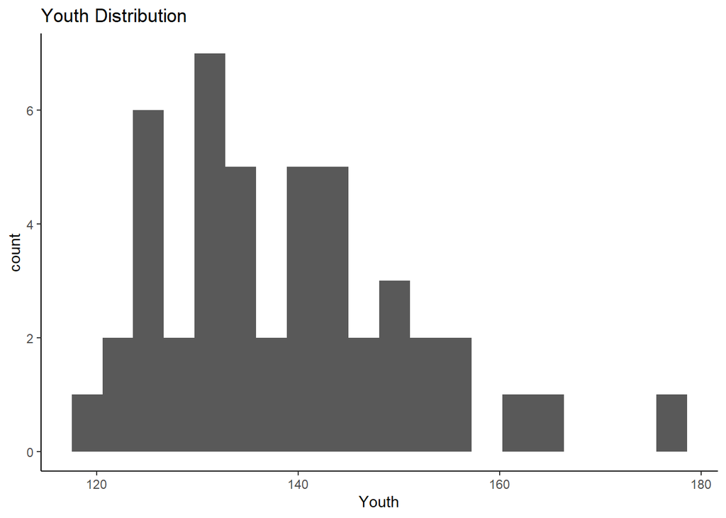

```r
ggplot(data = crime, aes(x=Youth)) + geom_histogram(bins = 20) + theme_classic()+ ggtitle("Youth Distribution")
```

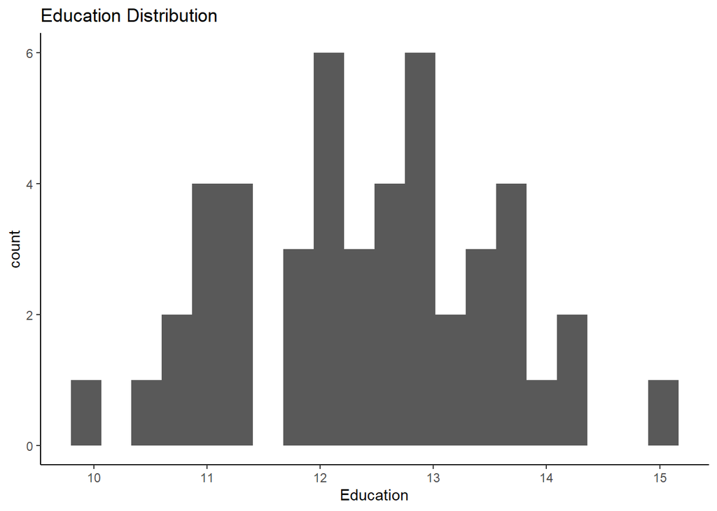

```r
ggplot(data = crime, aes(x=Education)) + geom_histogram(bins = 20) + theme_classic()+ ggtitle("Education Distribution")
```

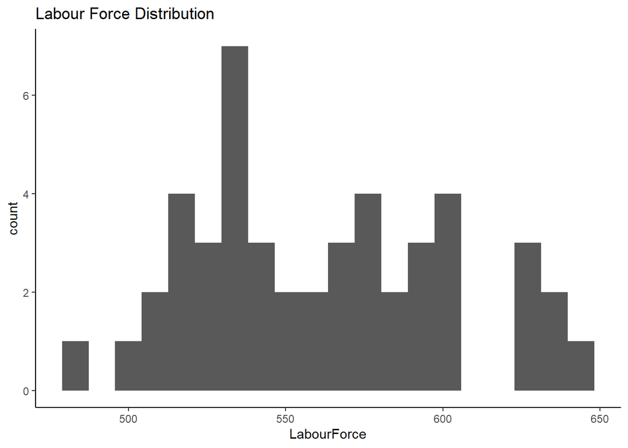

```r
ggplot(data = crime, aes(x=LabourForce)) + geom_histogram(bins = 20) + theme_classic() + ggtitle("Labour Force Distribution")
```

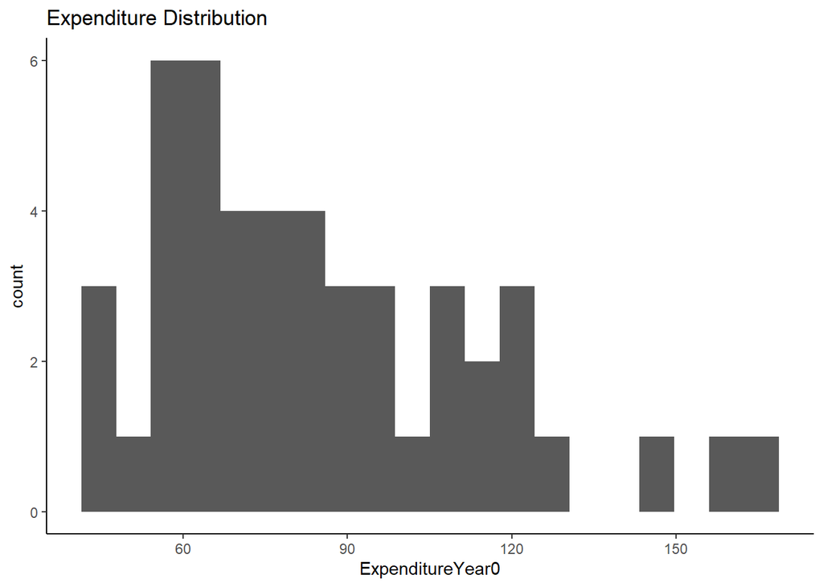

```r
ggplot(data = crime, aes(x=ExpenditureYear0)) + geom_histogram(bins = 20) + theme_classic() + ggtitle("Expenditure Distribution")
```

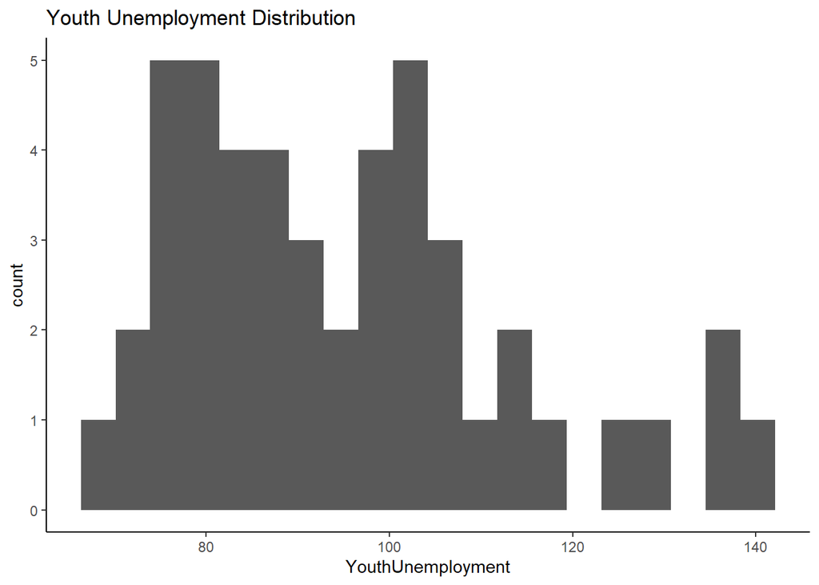

```r
ggplot(data = crime, aes(x=YouthUnemployment)) + geom_histogram(bins = 20) + theme_classic()+ ggtitle("Youth Unemployment Distribution")
```

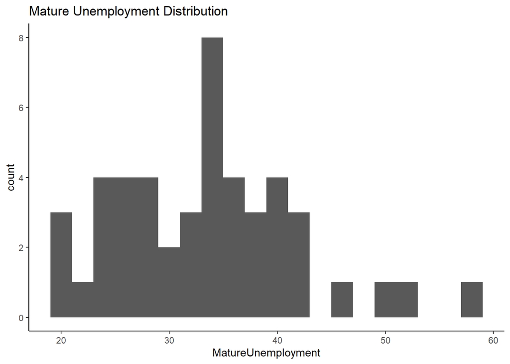

```r
ggplot(data = crime, aes(x=MatureUnemployment)) + geom_histogram(bins = 20) + theme_classic() + ggtitle("Mature Unemployment Distribution")
```

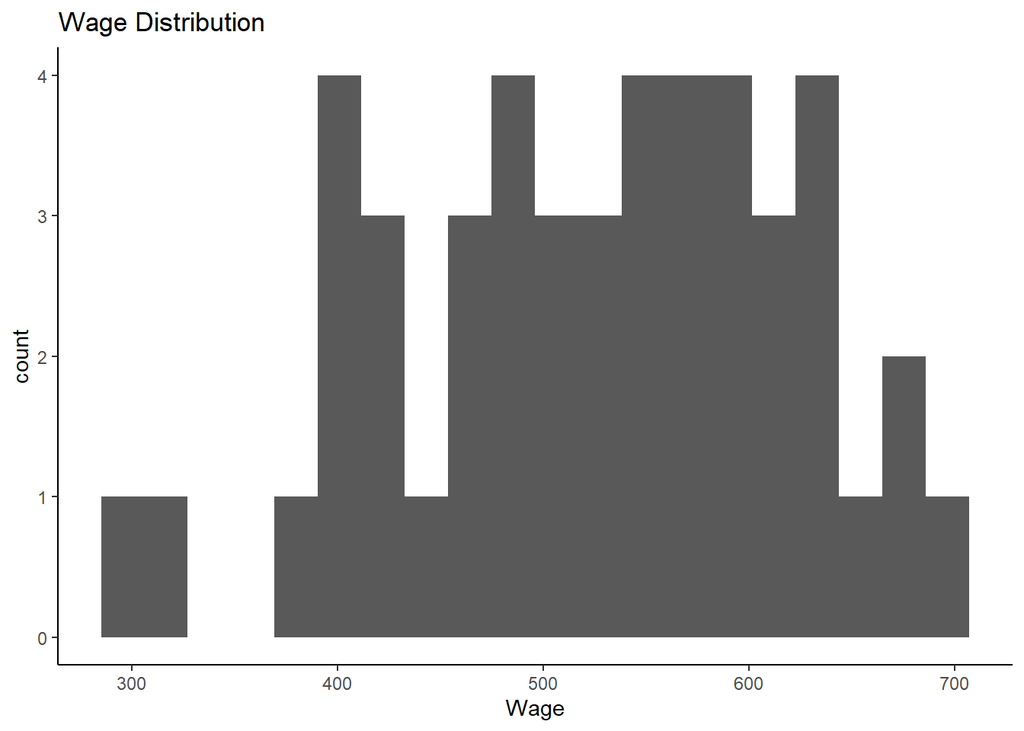

```r
ggplot(data = crime, aes(x=Wage)) + geom_histogram(bins = 20) + theme_classic() + ggtitle("Wage Distribution")
```

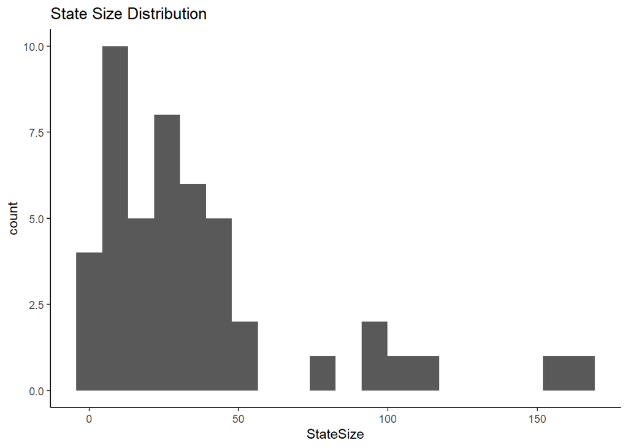

```r
ggplot(data = crime, aes(x=StateSize)) + geom_histogram(bins = 20) + theme_classic() + ggtitle("State Size Distribution")
```

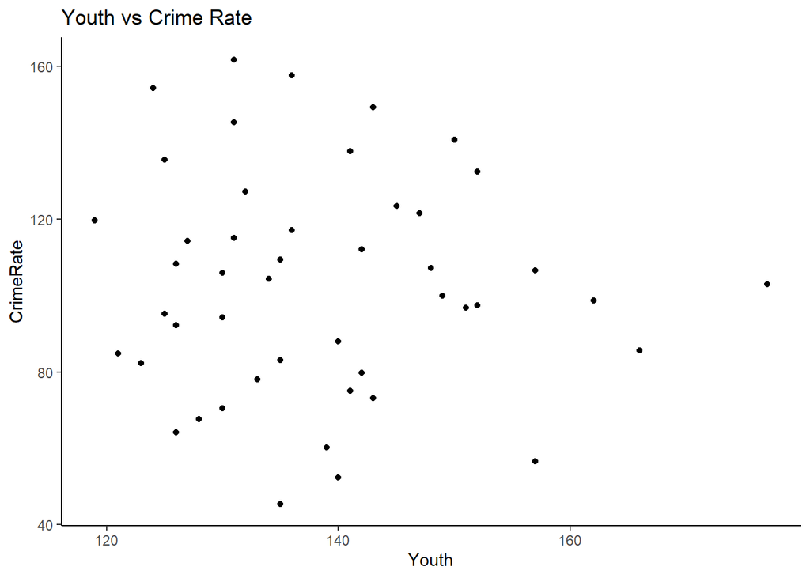

```r
ggplot(data = crime, aes(x=Youth, y=CrimeRate)) + geom_point() + theme_classic() + ggtitle("Youth vs Crime Rate")
```

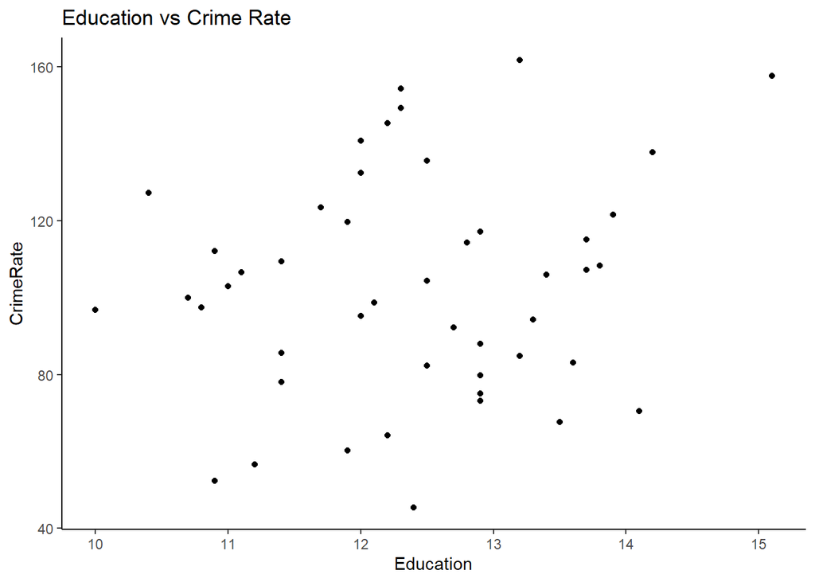

```r
ggplot(data = crime, aes(x=Education, y=CrimeRate)) + geom_point() + theme_classic()+ ggtitle("Education vs Crime Rate")
```

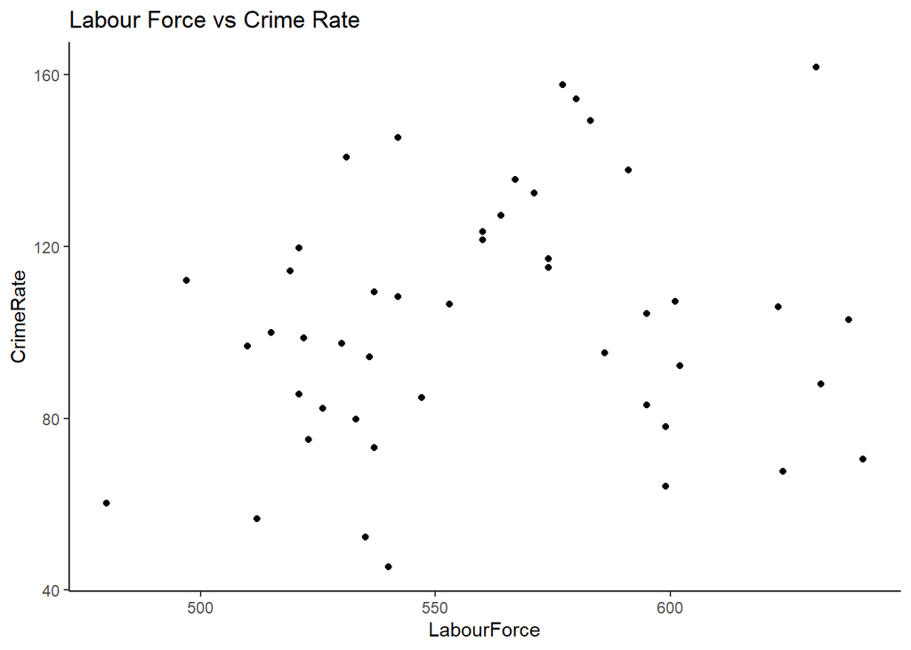

```r
ggplot(data = crime, aes(x=LabourForce, y=CrimeRate)) + geom_point()  + theme_classic()+ ggtitle("Labour Force vs Crime Rate")
```

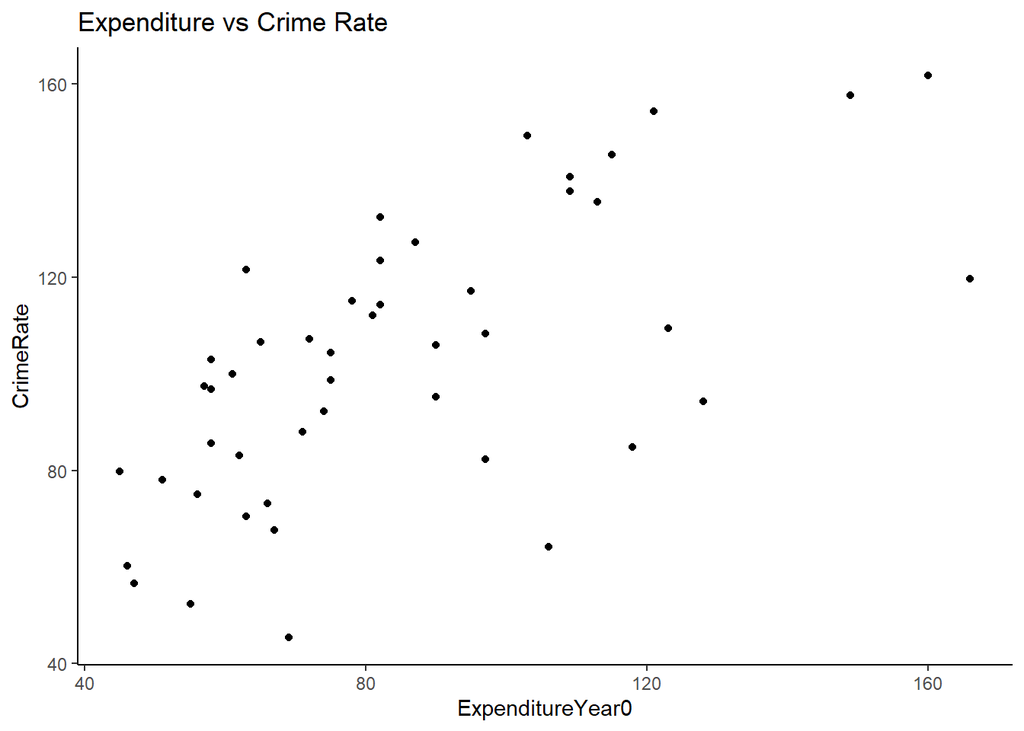

```r
ggplot(data = crime, aes(x=ExpenditureYear0, y=CrimeRate)) + geom_point()  + theme_classic() + ggtitle("Expenditure vs Crime Rate")
```

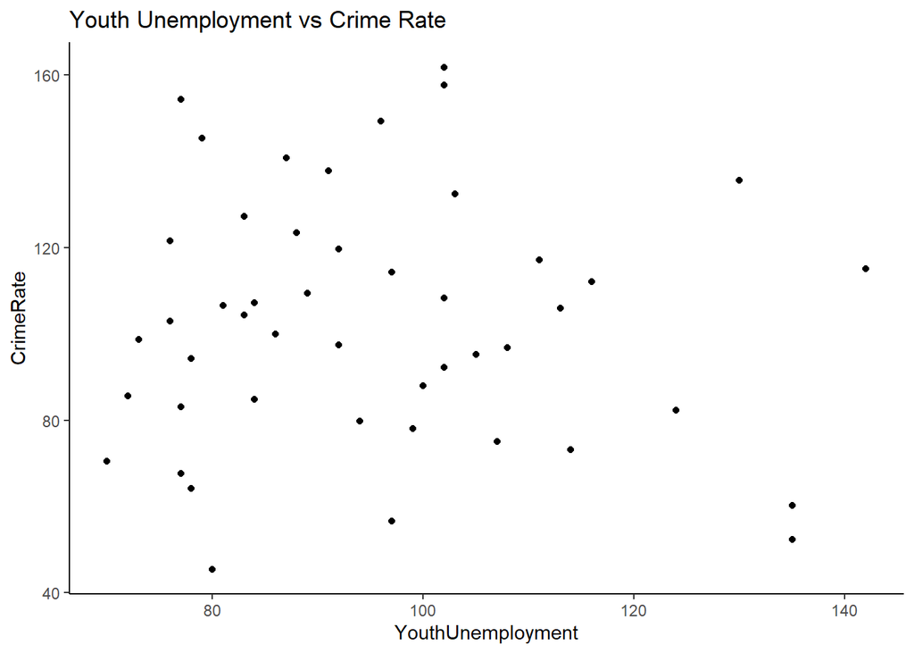

```r
ggplot(data = crime, aes(x=YouthUnemployment, y=CrimeRate)) + geom_point()  + theme_classic()+ ggtitle("Youth Unemployment vs Crime Rate")
```

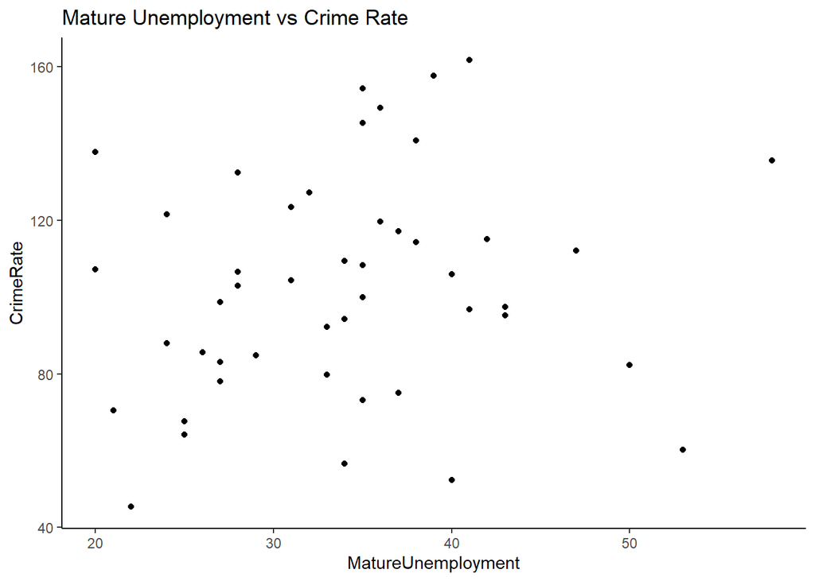

```r
ggplot(data = crime, aes(x=MatureUnemployment, y=CrimeRate)) + geom_point()  + theme_classic() + ggtitle("Mature Unemployment vs Crime Rate")
```

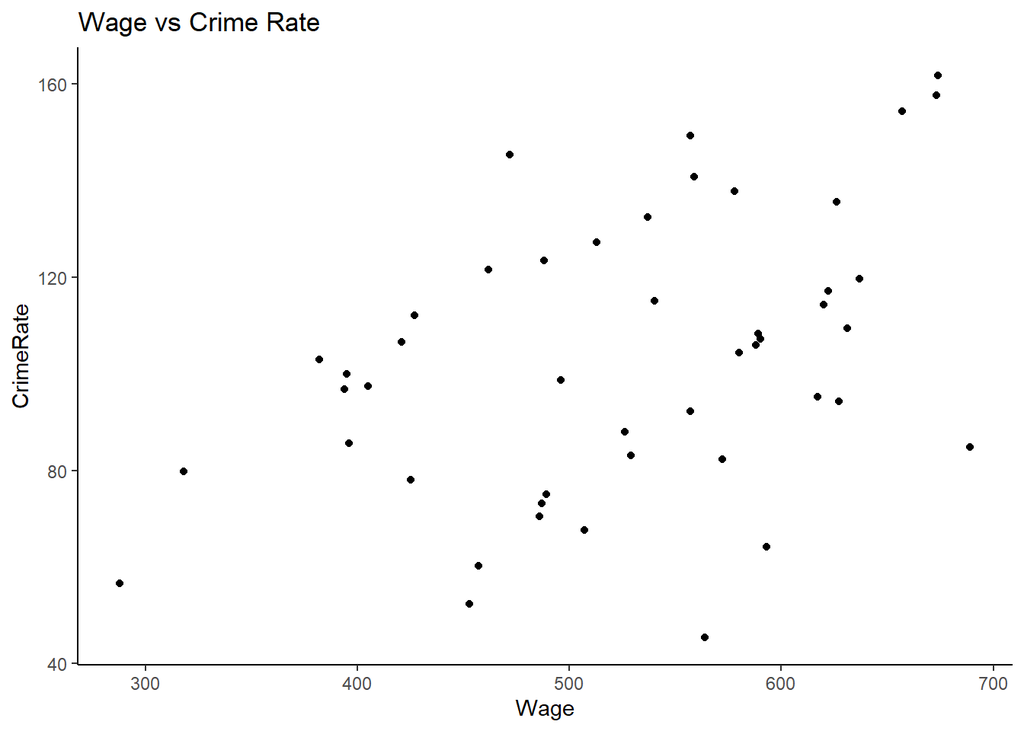

```r
ggplot(data = crime, aes(x=Wage, y=CrimeRate)) + geom_point()  + theme_classic()+ ggtitle("Wage vs Crime Rate")
```

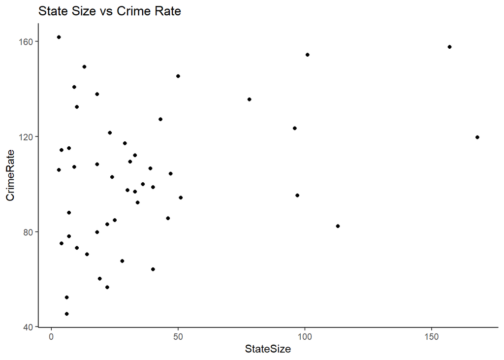

```r
ggplot(data = crime, aes(x=StateSize, y=CrimeRate)) + geom_point() + theme_classic()+ ggtitle("State Size vs Crime Rate")
```

The collection of scatter plots do not show that any of the variables is clearly linear, but some show a linear trend.

## 3. Focusing only on the continuous explanatory variables - check their correlations with the CrimeRate.

We want to do this only for the continuous variables, so can look to remove the column that is binary from this plot. (This is done so that the pairs plot is legible and that we can run a corr function on the resulting dataframe)

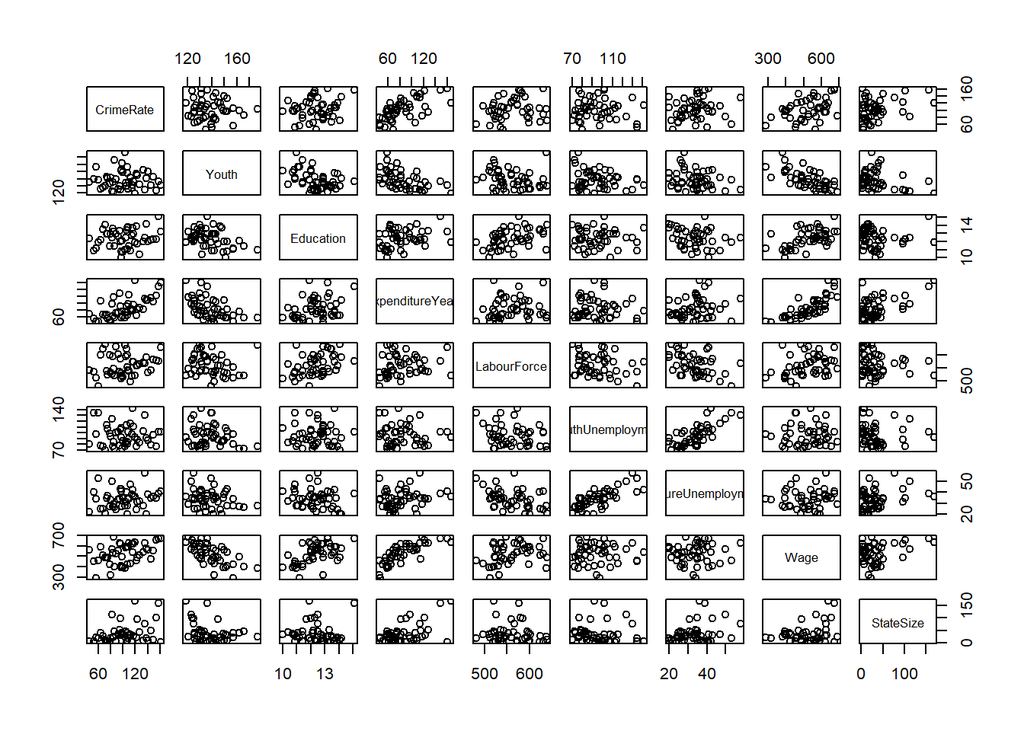

```r
crime.cont<-subset(crime, select=c("CrimeRate", "Youth", "Education", "ExpenditureYear0", "LabourForce",  "YouthUnemployment", "MatureUnemployment",
                                   "Wage", "StateSize") )
pairs(crime.cont)
```

```r
cor(crime.cont)
```

```
##                      CrimeRate       Youth    Education ExpenditureYear0
## CrimeRate           1.00000000 -0.05500217  0.157004661       0.64621060
## Youth              -0.05500217  1.00000000 -0.404477055      -0.50573690
## Education           0.15700466 -0.40447706  1.000000000       0.30001793
## ExpenditureYear0    0.64621060 -0.50573690  0.300017928       1.00000000
## LabourForce         0.16930857 -0.16094882  0.427860495       0.12149320
## YouthUnemployment  -0.05061320 -0.22438060 -0.026598090      -0.04369761
## MatureUnemployment  0.17183509 -0.24484339 -0.222656114       0.18509304
## Wage                0.42485301 -0.67005506  0.519186826       0.78722528
## StateSize           0.30794545 -0.28063762 -0.001403251       0.52628358
##                    LabourForce YouthUnemployment MatureUnemployment        Wage
## CrimeRate            0.1693086       -0.05061320         0.17183509  0.42485301
## Youth               -0.1609488       -0.22438060        -0.24484339 -0.67005506
## Education            0.4278605       -0.02659809        -0.22265611  0.51918683
## ExpenditureYear0     0.1214932       -0.04369761         0.18509304  0.78722528
## LabourForce          1.0000000       -0.22939968        -0.42076249  0.29463231
## YouthUnemployment   -0.2293997        1.00000000         0.74592482  0.04485720
## MatureUnemployment  -0.4207625        0.74592482         1.00000000  0.09207166
## Wage                 0.2946323        0.04485720         0.09207166  1.00000000
## StateSize           -0.1236722       -0.03811995         0.27042159  0.30826271
##                       StateSize
## CrimeRate           0.307945450
## Youth              -0.280637618
## Education          -0.001403251
## ExpenditureYear0    0.526283581
## LabourForce        -0.123672219
## YouthUnemployment  -0.038119948
## MatureUnemployment  0.270421586
## Wage                0.308262709
## StateSize           1.000000000
```

## 4. Using the continuous explanatory variables decide on a maximal model for CrimeRate and run it.

```r
crime.lm<-lm(crime$CrimeRate~crime$Youth+crime$Education+crime$ExpenditureYear0+crime$MatureUnemployment + crime$LabourForce+crime$YouthUnemployment+crime$StateSize + crime$Wage)

summary(crime.lm)
```

```
##
## Call:
## lm(formula = crime$CrimeRate ~ crime$Youth + crime$Education +
##     crime$ExpenditureYear0 + crime$MatureUnemployment + crime$LabourForce +
##     crime$YouthUnemployment + crime$StateSize + crime$Wage)
##
## Residuals:
##     Min      1Q  Median      3Q     Max
## -39.247 -14.381   0.036  10.666  34.043
##
## Coefficients:
##                            Estimate Std. Error t value Pr(>|t|)
## (Intercept)              -245.73727   95.19350  -2.581 0.013821 *
## crime$Youth                 1.03168    0.34474   2.993 0.004840 **
## crime$Education             2.47864    3.57762   0.693 0.492637
## crime$ExpenditureYear0      0.76387    0.19792   3.860 0.000427 ***
## crime$MatureUnemployment    1.29001    0.69947   1.844 0.072952 .
## crime$LabourForce           0.16571    0.09197   1.802 0.079515 .
## crime$YouthUnemployment    -0.22757    0.29351  -0.775 0.442938
## crime$StateSize            -0.03859    0.10125  -0.381 0.705212
## crime$Wage                 -0.00714    0.06657  -0.107 0.915155
## ---
## Signif. codes:  0 '***' 0.001 '**' 0.01 '*' 0.05 '.' 0.1 ' ' 1
##
## Residual standard error: 20.51 on 38 degrees of freedom
## Multiple R-squared:  0.5836, Adjusted R-squared:  0.4959
## F-statistic: 6.656 on 8 and 38 DF,  p-value: 2.015e-05
```

(NOTE: it is possible to start with a model that has interactions, all interactions could be used or a Tree approach can help understand if the relationship between an explanatory variable and the target variable is different based on the value (or range) of the explanatory variable - page 199 Crawley)

## 5. Use a model selection approach to achieve a minimal adequate model

Initially I will use all the continuous variables as explanatory variables as my starting maximal model. Then use the step function:

```r
step(crime.lm)
```

```
## Start:  AIC=292
## crime$CrimeRate ~ crime$Youth + crime$Education + crime$ExpenditureYear0 +
##     crime$MatureUnemployment + crime$LabourForce + crime$YouthUnemployment +
##     crime$StateSize + crime$Wage
##
##                            Df Sum of Sq   RSS    AIC
## - crime$Wage                1       4.8 15997 290.01
## - crime$StateSize           1      61.1 16053 290.17
## - crime$Education           1     202.0 16194 290.58
## - crime$YouthUnemployment   1     253.0 16245 290.73
## <none>                                  15992 292.00
## - crime$LabourForce         1    1366.2 17358 293.85
## - crime$MatureUnemployment  1    1431.4 17423 294.02
## - crime$Youth               1    3768.9 19761 299.94
## - crime$ExpenditureYear0    1    6268.9 22261 305.54
##
## Step:  AIC=290.01
## crime$CrimeRate ~ crime$Youth + crime$Education + crime$ExpenditureYear0 +
##     crime$MatureUnemployment + crime$LabourForce + crime$YouthUnemployment +
##     crime$StateSize
##
##                            Df Sum of Sq   RSS    AIC
## - crime$StateSize           1      57.7 16054 288.18
## - crime$Education           1     199.8 16196 288.59
## - crime$YouthUnemployment   1     260.7 16257 288.77
## <none>                                  15997 290.01
## - crime$LabourForce         1    1371.3 17368 291.88
## - crime$MatureUnemployment  1    1446.3 17443 292.08
## - crime$Youth               1    4748.9 20746 300.23
## - crime$ExpenditureYear0    1   11682.9 27680 313.78
##
## Step:  AIC=288.18
## crime$CrimeRate ~ crime$Youth + crime$Education + crime$ExpenditureYear0 +
##     crime$MatureUnemployment + crime$LabourForce + crime$YouthUnemployment
##
##                            Df Sum of Sq   RSS    AIC
## - crime$Education           1     211.2 16266 286.79
## - crime$YouthUnemployment   1     216.8 16271 286.81
## <none>                                  16054 288.18
## - crime$MatureUnemployment  1    1391.9 17446 290.09
```

[output cut: 11 more lines]

```
## - crime$MatureUnemployment  1    1185.1 17451 288.10
## - crime$LabourForce         1    1796.2 18062 289.72
## - crime$Youth               1    4698.3 20964 296.72
## - crime$ExpenditureYear0    1   14469.2 30735 314.70
##
## Step:  AIC=285.17
## crime$CrimeRate ~ crime$Youth + crime$ExpenditureYear0 + crime$MatureUnemployment +
##     crime$LabourForce
##
##                            Df Sum of Sq   RSS    AIC
## <none>                                  16395 285.17
## - crime$MatureUnemployment  1    1519.6 17915 287.33
## - crime$LabourForce         1    1684.0 18079 287.76
## - crime$Youth               1    5215.0 21610 296.15
## - crime$ExpenditureYear0    1   17961.5 34357 317.94
```

```
##
## Call:
## lm(formula = crime$CrimeRate ~ crime$Youth + crime$ExpenditureYear0 +
##     crime$MatureUnemployment + crime$LabourForce)
##
## Coefficients:
##              (Intercept)               crime$Youth    crime$ExpenditureYear0
##                -230.0179                    1.0244                    0.7763
## crime$MatureUnemployment         crime$LabourForce
##                   0.8054                    0.1738
```

The step function has ended with this minimal adequate model:

crime$CrimeRate ~ crime$Youth + crime$ExpenditureYear0 + crime$MatureUnemployment + crime$LabourForce

## 6. Once you have the minimal adequate model (from the step function), explain its findings and test its residuals

```r
mam.lm<-lm(formula = crime$CrimeRate ~ crime$Youth + crime$ExpenditureYear0 +
    crime$MatureUnemployment + crime$LabourForce)

summary(mam.lm)
```

```
##
## Call:
## lm(formula = crime$CrimeRate ~ crime$Youth + crime$ExpenditureYear0 +
##     crime$MatureUnemployment + crime$LabourForce)
##
## Residuals:
##     Min      1Q  Median      3Q     Max
## -41.368 -13.984   1.552  11.017  35.482
##
## Coefficients:
##                            Estimate Std. Error t value Pr(>|t|)
## (Intercept)              -230.01795   77.24501  -2.978 0.004805 **
## crime$Youth                 1.02436    0.28026   3.655 0.000709 ***
## crime$ExpenditureYear0      0.77626    0.11444   6.783 2.97e-08 ***
## crime$MatureUnemployment    0.80540    0.40821   1.973 0.055100 .
## crime$LabourForce           0.17379    0.08367   2.077 0.043956 *
## ---
## Signif. codes:  0 '***' 0.001 '**' 0.01 '*' 0.05 '.' 0.1 ' ' 1
##
## Residual standard error: 19.76 on 42 degrees of freedom
## Multiple R-squared:  0.5731, Adjusted R-squared:  0.5324
## F-statistic: 14.09 on 4 and 42 DF,  p-value: 2.253e-07
```

From the model summary for this minimal adequate model (mam.lm) we can see that crime rate is dependent on the variables Youth, ExpenditureYear0 and LabourForce. In all these cases an increase in their value increases the crime rate estimate.

$$CrimeRate= -230.01795 +1.02436\times
Youth+ 0.77626 \times ExpenditureYear0 + 0.80540 \times
MatureUnemployment + 0.17379 \times LabourForce$$

Next the residuals should be scrutinized:

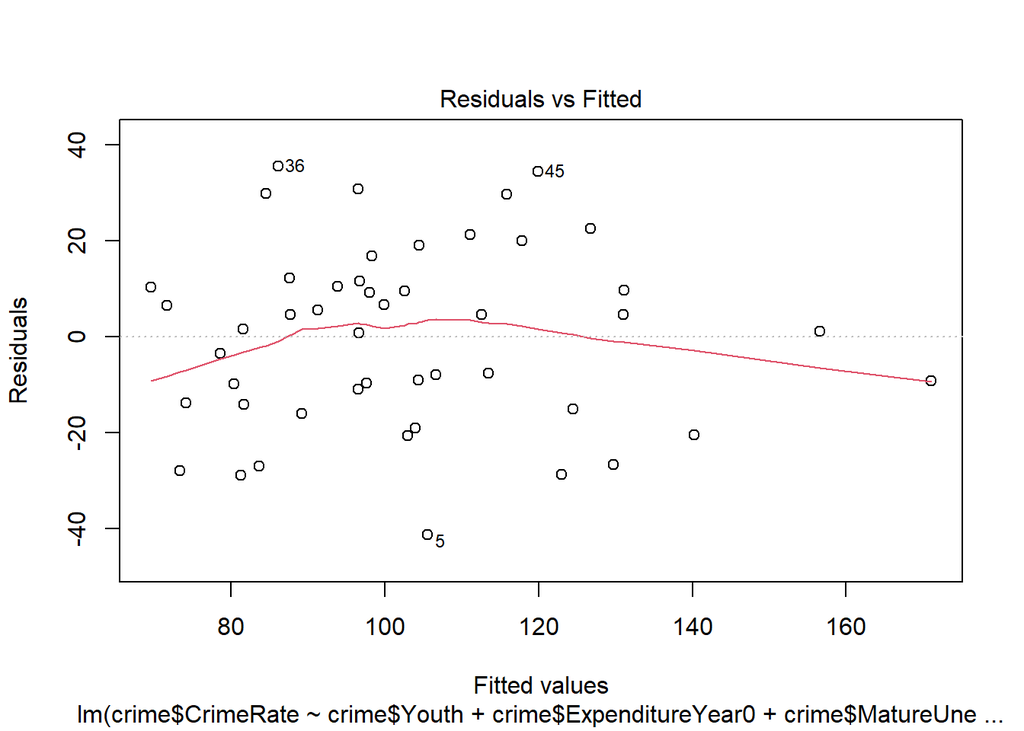

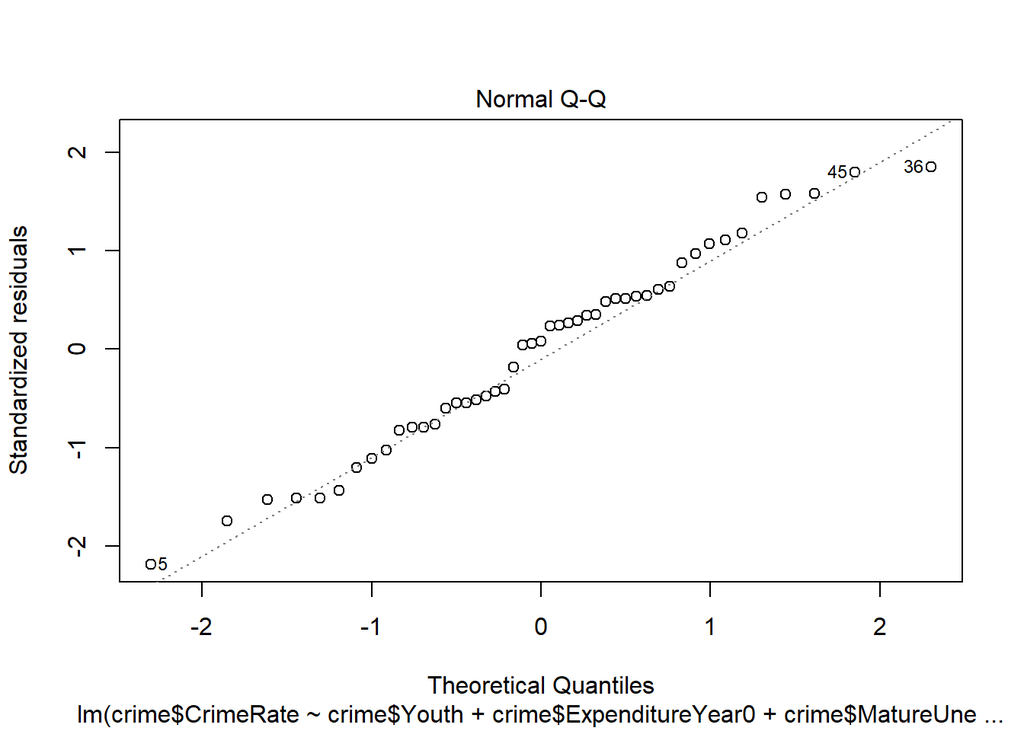

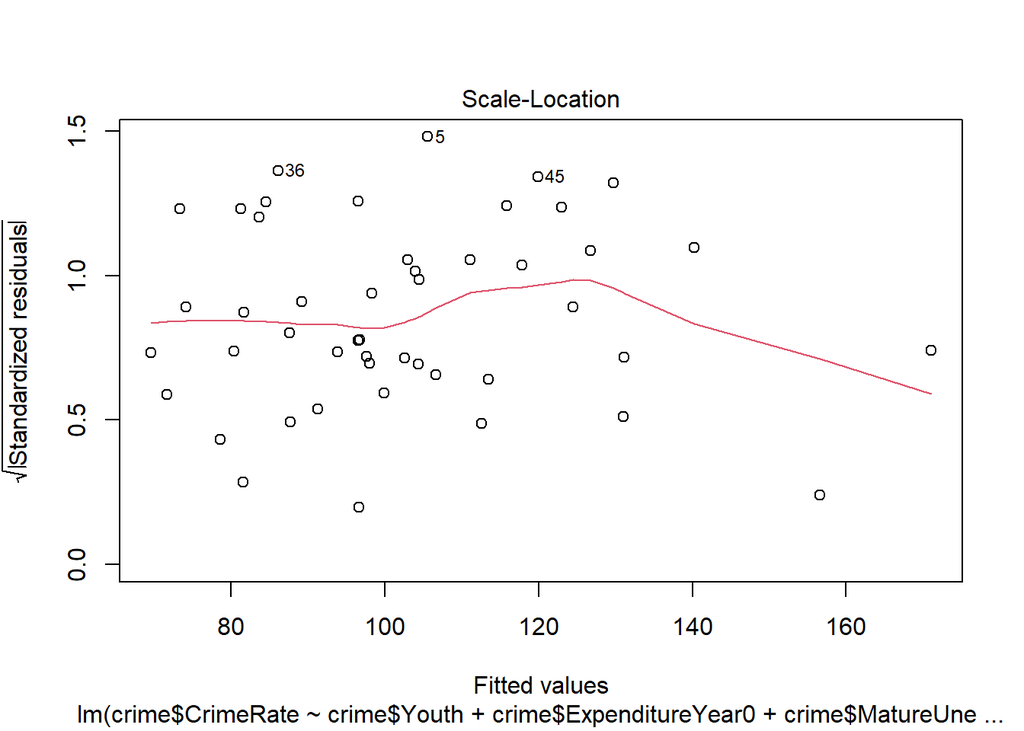

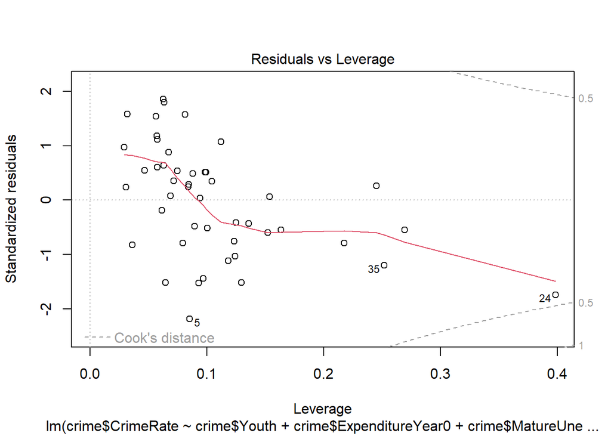

```r
plot(mam.lm)
```

In this case the residuals look ok, the variance is quite steady in the first plot - considering the data size. QQ plot also looks aligned, with a few points standing out as outliers. We could explore these in more detail but as the model is good there may be no need to.

## 7. OPTIONAL - model the relationship between the crime rate and the explanatory variables (including the ones that are not continuous).

Instead of only including the continuous variables in the model we can now add them all in, including the factor variable.

```r
model.all.lm<-lm(crime$CrimeRate~crime$Youth+crime$Education+crime$ExpenditureYear0
                 +crime$MatureUnemployment + crime$LabourForce+crime$YouthUnemployment+crime$StateSize + crime$Wage+ crime$HighYouthUnemploy)

summary(model.all.lm)
```

```
##
## Call:
## lm(formula = crime$CrimeRate ~ crime$Youth + crime$Education +
##     crime$ExpenditureYear0 + crime$MatureUnemployment + crime$LabourForce +
##     crime$YouthUnemployment + crime$StateSize + crime$Wage +
##     crime$HighYouthUnemploy)
##
## Residuals:
##     Min      1Q  Median      3Q     Max
## -38.035 -13.917  -0.117  10.854  34.331
##
## Coefficients:
##                            Estimate Std. Error t value Pr(>|t|)
## (Intercept)              -2.442e+02  9.659e+01  -2.528 0.015875 *
## crime$Youth               1.011e+00  3.587e-01   2.818 0.007720 **
## crime$Education           2.447e+00  3.625e+00   0.675 0.503810
## crime$ExpenditureYear0    7.588e-01  2.014e-01   3.768 0.000573 ***
## crime$MatureUnemployment  1.108e+00  1.005e+00   1.103 0.277285
## crime$LabourForce         1.704e-01  9.495e-02   1.795 0.080817 .
## crime$YouthUnemployment  -1.595e-01  3.994e-01  -0.399 0.691987
## crime$StateSize          -3.932e-02  1.026e-01  -0.383 0.703596
## crime$Wage               -6.841e-03  6.741e-02  -0.101 0.919722
## crime$HighYouthUnemploy1 -2.962e+00  1.161e+01  -0.255 0.800053
## ---
## Signif. codes:  0 '***' 0.001 '**' 0.01 '*' 0.05 '.' 0.1 ' ' 1
##
## Residual standard error: 20.77 on 37 degrees of freedom
## Multiple R-squared:  0.5843, Adjusted R-squared:  0.4832
## F-statistic: 5.778 on 9 and 37 DF,  p-value: 5.365e-05
```

The $r^2 $is higher than for the model without the factors but lets see what a step process would achieve in terms of simplifying the model:

```r
step(model.all.lm)
```

```
## Start:  AIC=293.91
## crime$CrimeRate ~ crime$Youth + crime$Education + crime$ExpenditureYear0 +
##     crime$MatureUnemployment + crime$LabourForce + crime$YouthUnemployment +
##     crime$StateSize + crime$Wage + crime$HighYouthUnemploy
##
##                            Df Sum of Sq   RSS    AIC
## - crime$Wage                1       4.4 15968 291.93
## - crime$HighYouthUnemploy   1      28.1 15992 292.00
## - crime$StateSize           1      63.4 16027 292.10
## - crime$YouthUnemployment   1      68.8 16032 292.11
## - crime$Education           1     196.6 16160 292.49
## - crime$MatureUnemployment  1     524.6 16488 293.43
## <none>                                  15964 293.91
## - crime$LabourForce         1    1390.2 17354 295.84
## - crime$Youth               1    3425.3 19389 301.05
## - crime$ExpenditureYear0    1    6126.5 22090 307.18
##
## Step:  AIC=291.93
## crime$CrimeRate ~ crime$Youth + crime$Education + crime$ExpenditureYear0 +
##     crime$MatureUnemployment + crime$LabourForce + crime$YouthUnemployment +
##     crime$StateSize + crime$HighYouthUnemploy
##
##                            Df Sum of Sq   RSS    AIC
## - crime$HighYouthUnemploy   1      28.5 15997 290.01
## - crime$StateSize           1      60.1 16028 290.10
## - crime$YouthUnemployment   1      70.8 16039 290.13
## - crime$Education           1     195.0 16163 290.50
## - crime$MatureUnemployment  1     527.9 16496 291.45
## <none>                                  15968 291.93
## - crime$LabourForce         1    1395.1 17363 293.86
## - crime$Youth               1    4244.4 20213 301.00
## - crime$ExpenditureYear0    1   11378.4 27347 315.21
##
## Step:  AIC=290.01
## crime$CrimeRate ~ crime$Youth + crime$Education + crime$ExpenditureYear0 +
##     crime$MatureUnemployment + crime$LabourForce + crime$YouthUnemployment +
##     crime$StateSize
##
##                            Df Sum of Sq   RSS    AIC
## - crime$StateSize           1      57.7 16054 288.18
```

[output cut: 28 more lines]

```
## - crime$MatureUnemployment  1    1185.1 17451 288.10
## - crime$LabourForce         1    1796.2 18062 289.72
## - crime$Youth               1    4698.3 20964 296.72
## - crime$ExpenditureYear0    1   14469.2 30735 314.70
##
## Step:  AIC=285.17
## crime$CrimeRate ~ crime$Youth + crime$ExpenditureYear0 + crime$MatureUnemployment +
##     crime$LabourForce
##
##                            Df Sum of Sq   RSS    AIC
## <none>                                  16395 285.17
## - crime$MatureUnemployment  1    1519.6 17915 287.33
## - crime$LabourForce         1    1684.0 18079 287.76
## - crime$Youth               1    5215.0 21610 296.15
## - crime$ExpenditureYear0    1   17961.5 34357 317.94
```

```
##
## Call:
## lm(formula = crime$CrimeRate ~ crime$Youth + crime$ExpenditureYear0 +
##     crime$MatureUnemployment + crime$LabourForce)
##
## Coefficients:
##              (Intercept)               crime$Youth    crime$ExpenditureYear0
##                -230.0179                    1.0244                    0.7763
## crime$MatureUnemployment         crime$LabourForce
##                   0.8054                    0.1738
```

The binary (factor) variable we added as part of the explanatory variables does not add much and this is confirmed as the step process proposes a model that does not include it as an explanatory variable.

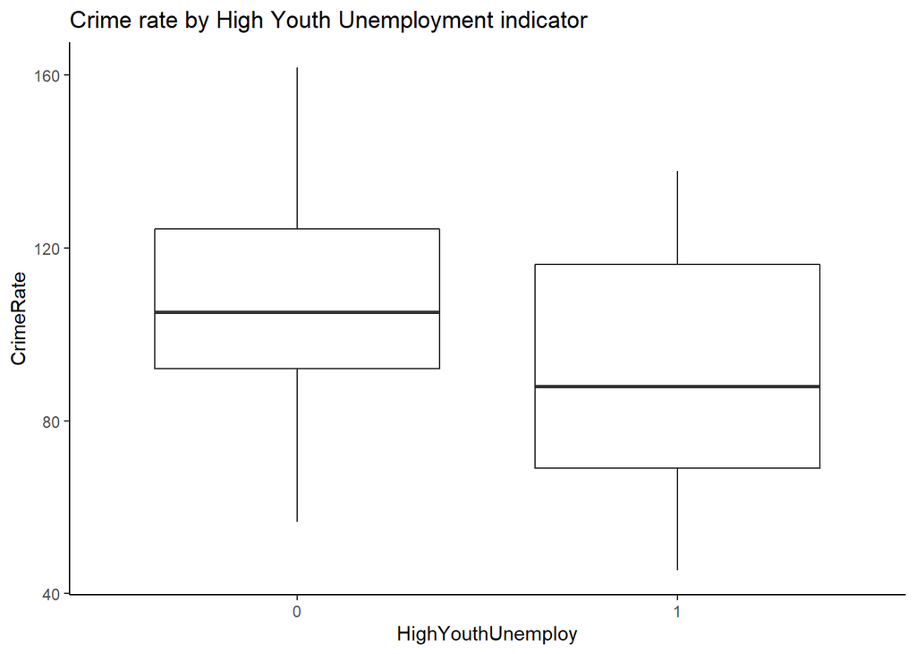

```r
ggplot(crime, aes(x=HighYouthUnemploy, y=CrimeRate)) + geom_boxplot() + ggtitle("Crime rate by High Youth Unemployment indicator")+ theme_classic()
```

Therefore the model from section 6 is probably still the most suitable one to use to answer the question asked “what variables affect the crime rate and how?”.

```r
education.mean<-mean(crime$Education)
education.mean
```

```
## [1] 12.39149
```

We will be testing the following hypotheses: $H_0: \mu=14$ and $H_1: \mu < 14$.

```r
t.test(crime$Education, mu=14, alternative = "less" )
```

```
##
##  One Sample t-test
##
## data:  crime$Education
## t = -9.843, df = 46, p-value = 3.358e-13
## alternative hypothesis: true mean is less than 14
## 95 percent confidence interval:
##      -Inf 12.66581
## sample estimates:
## mean of x
##  12.39149
```

This is a very small p-value, so we have evidence to reject the null hypothesis in this case. The mean education for this sample of data is significantly lower than that for the population.

### OPTIONAL - If you want to use a Regression Tree to check for interactions:

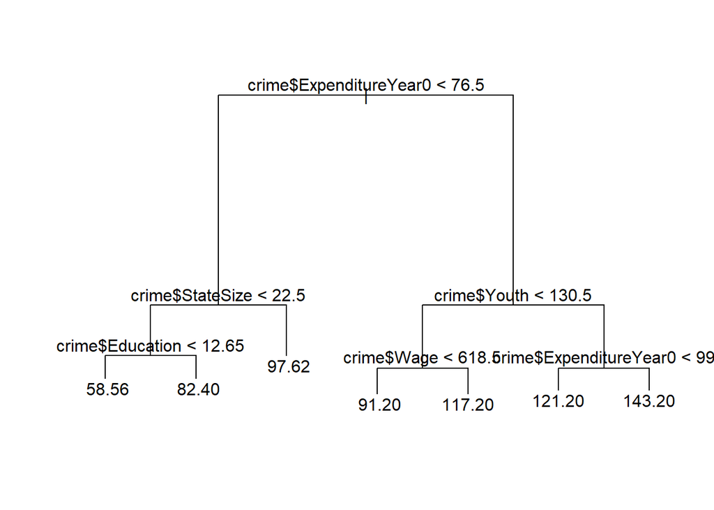

```r
library(tree)
crime.tree<-tree(crime$CrimeRate~crime$Youth+crime$Education+crime$ExpenditureYear0+crime$MatureUnemployment + crime$LabourForce+crime$YouthUnemployment+crime$StateSize + crime$Wage)
plot(crime.tree)
text(crime.tree)
```

From this tree there are no “contradictions” in direction of the estimate. (see page 199 of Crawley for an example), therefore this does not point to the need for interactions in this case.